# Modelling

Jono Tuke

2019-12-06

# 1 Read in clean data

```r
# TSH_long  <- read_rds("../data/20190716-02_convert_long.rds")
# TSH_long  <- read_rds("../data/2019082-02_convert_long.rds")
# TSH_long  <- read_rds("../data/20190716-02_convert_long.rds")
TSH_long  <- read_rds("../data/20191205-02_convert_long.rds")
```

# 2 Modelling

## 2.1 Three thyroid tests

We will use a mixed-effect model with the paper ID as a random intercept and thyroid method as a fixed effect.

Need to convert `Sig` to factor. Also remove missing

```r
TSH_long  <-
  TSH_long %>%
  mutate(Sig = factor(Sig))
```

```r
TSH_long <-
  TSH_long %>% filter(!is.na(Sig))
```

Convert Thyroid test to factor

```r
TSH_long  <-
  TSH_long %>%
  mutate(
    Thyroid_test = factor(Thyroid_test)
  )
```

Load necessary packages

```r
pacman::p_load(lme4, lmerTest)
```

### 2.1.1 Random effects

Start with single fixed effect - thyroid test, and single random intercept (RI) for each paper.

```r
tsh_glmer  <- glmer(Sig ~ Thyroid_test + (1 | Paper), data = TSH_long, family = binomial)
```

Compare model to one without RI.

```r
tsh_glm  <- glm(Sig ~ Thyroid_test, data = TSH_long, family = binomial)
anova(tsh_glmer, tsh_glm)
```

```
## Data: TSH_long
## Models:
## tsh_glm: Sig ~ Thyroid_test
## tsh_glmer: Sig ~ Thyroid_test + (1 | Paper)
##           Df    AIC    BIC  logLik deviance  Chisq Chi Df Pr(>Chisq)
## tsh_glm    3 2346.5 2363.2 -1170.3   2340.5
## tsh_glmer  4 2050.6 2072.8 -1021.3   2042.6 297.92      1  < 2.2e-16 ***
## ---
## Signif. codes:  0 '***' 0.001 '**' 0.01 '*' 0.05 '.' 0.1 ' ' 1
```

Looks like need RI.

### 2.1.2 Fixed effects

Test for significant differences between tests.

```r
tsh_glmer_null  <- glmer(Sig ~ 1 + (1 | Paper), data = TSH_long, family = binomial)
anova(tsh_glmer, tsh_glmer_null)
```

```
## Data: TSH_long
## Models:
## tsh_glmer_null: Sig ~ 1 + (1 | Paper)
## tsh_glmer: Sig ~ Thyroid_test + (1 | Paper)
##                Df    AIC    BIC  logLik deviance  Chisq Chi Df Pr(>Chisq)
## tsh_glmer_null  2 2231.8 2242.8 -1113.9   2227.8
## tsh_glmer       4 2050.6 2072.8 -1021.3   2042.6 185.14      2  < 2.2e-16 ***
## ---
## Signif. codes:  0 '***' 0.001 '**' 0.01 '*' 0.05 '.' 0.1 ' ' 1
```

Looks like significant effect of test.

Also check with BIC - smaller is better.

```r
BIC(tsh_glmer_null, tsh_glm, tsh_glmer)
```

```
##                df      BIC
## tsh_glmer_null  2 2242.830
## tsh_glm         3 2363.157
## tsh_glmer       4 2072.771
```

So far best model is fixed effect of test with RI.

```r
summary(tsh_glmer)
```

```
## Generalized linear mixed model fit by maximum likelihood (Laplace
##   Approximation) [glmerMod]
##  Family: binomial  ( logit )
## Formula: Sig ~ Thyroid_test + (1 | Paper)
##    Data: TSH_long
##
##      AIC      BIC   logLik deviance df.resid
##   2050.6   2072.8  -1021.3   2042.6     1876
##
## Scaled residuals:
##     Min      1Q  Median      3Q     Max
## -3.3372 -0.6359 -0.3137  0.7128  3.9238
##
## Random effects:
##  Groups Name        Variance Std.Dev.
##  Paper  (Intercept) 1.341    1.158
## Number of obs: 1880, groups:  Paper, 58
##
## Fixed effects:
##                 Estimate Std. Error z value Pr(>|z|)
## (Intercept)       0.2832     0.1802   1.572    0.116
## Thyroid_testT3   -0.1027     0.1799  -0.571    0.568
## Thyroid_testTSH  -1.5824     0.1273 -12.431   <2e-16 ***
## ---
## Signif. codes:  0 '***' 0.001 '**' 0.01 '*' 0.05 '.' 0.1 ' ' 1
##
## Correlation of Fixed Effects:
##             (Intr) Thy_T3
## Thyrd_tstT3 -0.202
## Thyrd_tsTSH -0.307  0.289
```

From this - look at fixed effect output. We have that TSH has a signicantly smaller probability of significance compared to T4. T3 and T4 are not significantly different.

### 2.1.3 Pairwise comparisons

```r
summary(glht(tsh_glmer, linfct = mcp(Thyroid_test = "Tukey")))
```

```
##
##   Simultaneous Tests for General Linear Hypotheses
##
## Multiple Comparisons of Means: Tukey Contrasts
##
##
## Fit: glmer(formula = Sig ~ Thyroid_test + (1 | Paper), data = TSH_long,
##     family = binomial)
##
## Linear Hypotheses:
##                Estimate Std. Error z value Pr(>|z|)
## T3 - FT4 == 0   -0.1027     0.1799  -0.571    0.833
## TSH - FT4 == 0  -1.5824     0.1273 -12.431   <1e-05 ***
## TSH - T3 == 0   -1.4797     0.1879  -7.874   <1e-05 ***
## ---
## Signif. codes:  0 '***' 0.001 '**' 0.01 '*' 0.05 '.' 0.1 ' ' 1
## (Adjusted p values reported -- single-step method)
```

So significant difference between

- TSH and Free T4, and
- TSH and T3.

## 2.2 Four thyroid tests

Will remove single T3

```r
TSH_long %>% count(Thyroid_test_4)
```

```
## # A tibble: 4 x 2
##   Thyroid_test_4     n
##   <chr>          <int>
## 1 FT4              813
## 2 T3_Free          183
## 3 T3_Total          71
## 4 TSH              813
```

### 2.2.1 Random effects

```r
tsh_glmer  <- glmer(Sig ~ Thyroid_test_4 + (1 | Paper),
                    data = TSH_long, family = binomial)
tsh_glm  <- glm(Sig ~ Thyroid_test_4,
                data = TSH_long, family = binomial)
anova(tsh_glmer, tsh_glm)
```

```
## Data: TSH_long
## Models:
## tsh_glm: Sig ~ Thyroid_test_4
## tsh_glmer: Sig ~ Thyroid_test_4 + (1 | Paper)
##           Df    AIC    BIC  logLik deviance  Chisq Chi Df Pr(>Chisq)
## tsh_glm    4 2328.9 2351.0 -1160.4   2320.9
## tsh_glmer  5 2050.0 2077.7 -1020.0   2040.0 280.82      1  < 2.2e-16 ***
## ---
## Signif. codes:  0 '***' 0.001 '**' 0.01 '*' 0.05 '.' 0.1 ' ' 1
```

So we need a random intercept.

### 2.2.2 Fixed effects

```r
tsh_glmer_null  <- glmer(Sig ~ 1 + (1 | Paper),
                         data = TSH_long, family = binomial)
anova(tsh_glmer, tsh_glmer_null)
```

```
## Data: TSH_long
## Models:
## tsh_glmer_null: Sig ~ 1 + (1 | Paper)
## tsh_glmer: Sig ~ Thyroid_test_4 + (1 | Paper)
##                Df    AIC    BIC  logLik deviance  Chisq Chi Df Pr(>Chisq)
## tsh_glmer_null  2 2231.8 2242.8 -1113.9   2227.8
## tsh_glmer       5 2050.0 2077.7 -1020.0   2040.0 187.71      3  < 2.2e-16 ***
## ---
## Signif. codes:  0 '***' 0.001 '**' 0.01 '*' 0.05 '.' 0.1 ' ' 1
```

So the treatments are significant.

```r
summary(tsh_glmer)
```

```
## Generalized linear mixed model fit by maximum likelihood (Laplace
##   Approximation) [glmerMod]
##  Family: binomial  ( logit )
## Formula: Sig ~ Thyroid_test_4 + (1 | Paper)
##    Data: TSH_long
##
##      AIC      BIC   logLik deviance df.resid
##   2050.0   2077.7  -1020.0   2040.0     1875
##
## Scaled residuals:
##     Min      1Q  Median      3Q     Max
## -3.3810 -0.6375 -0.3147  0.7144  3.9072
##
## Random effects:
##  Groups Name        Variance Std.Dev.
##  Paper  (Intercept) 1.32     1.149
## Number of obs: 1880, groups:  Paper, 58
##
## Fixed effects:
##                        Estimate Std. Error z value Pr(>|z|)
## (Intercept)              0.2854     0.1790   1.594    0.111
## Thyroid_test_4T3_Free   -0.2646     0.2066  -1.281    0.200
## Thyroid_test_4T3_Total   0.3707     0.3527   1.051    0.293
## Thyroid_test_4TSH       -1.5730     0.1269 -12.395   <2e-16 ***
## ---
## Signif. codes:  0 '***' 0.001 '**' 0.01 '*' 0.05 '.' 0.1 ' ' 1
##
## Correlation of Fixed Effects:
##             (Intr) T__4T3_F T__4T3_T
## Thyr__4T3_F -0.181
## Thyr__4T3_T -0.096  0.046
## Thyrd__4TSH -0.308  0.232    0.178
```

### 2.2.3 Pairwise comparisons

```r
summary(glht(tsh_glmer, linfct = mcp(Thyroid_test_4 = "Tukey")))
```

```
##
##   Simultaneous Tests for General Linear Hypotheses
##
## Multiple Comparisons of Means: Tukey Contrasts
##
##
## Fit: glmer(formula = Sig ~ Thyroid_test_4 + (1 | Paper), data = TSH_long,
##     family = binomial)
##
## Linear Hypotheses:
##                         Estimate Std. Error z value Pr(>|z|)
## T3_Free - FT4 == 0       -0.2646     0.2066  -1.281    0.549
## T3_Total - FT4 == 0       0.3707     0.3527   1.051    0.697
## TSH - FT4 == 0           -1.5730     0.1269 -12.395   <0.001 ***
## T3_Total - T3_Free == 0   0.6353     0.4004   1.587    0.359
## TSH - T3_Free == 0       -1.3084     0.2159  -6.059   <0.001 ***
## TSH - T3_Total == 0      -1.9437     0.3530  -5.507   <0.001 ***
## ---
## Signif. codes:  0 '***' 0.001 '**' 0.01 '*' 0.05 '.' 0.1 ' ' 1
## (Adjusted p values reported -- single-step method)
```

So significant difference between

- TSH and Free T4,
- TSH and Free T3, and
- TSH and Total T3.

## 2.3 Try adding in other covariates.

For these, we keep thyroid test and try adding in the given covariate, also try upto two-way interaction.

### 2.3.1 System

```r
system_models  <- get_cov("system")
system_models %>% arrange(BIC) %>% knitr::kable()
```

| sigma | logLik | AIC | BIC | deviance | df.residual | null.deviance | df.null | converge | models |
| --- | --- | --- | --- | --- | --- | --- | --- | --- | --- |
| 1 | -637.9930 | 1283.986 | 1303.991 | 1204.165 | 1094 | NA | NA | TRUE | test + RI |
| 1 | -625.7613 | 1275.523 | 1335.538 | 1185.558 | 1086 | NA | NA | TRUE | test + main + RI |
| NA | -640.3934 | 1302.787 | 1357.800 | 1280.787 | 1087 | 1486.25 | 1097 | TRUE | test + main |
| 1 | -590.2743 | 1236.549 | 1376.584 | 1113.024 | 1070 | NA | NA | FALSE | interaction + RI |
| NA | -681.0661 | 1368.132 | 1383.136 | 1362.132 | 1095 | 1486.25 | 1097 | TRUE | test |
| NA | -603.3479 | 1260.696 | 1395.729 | 1206.696 | 1071 | 1486.25 | 1097 | TRUE | interaction |

Best model (BIC) is thyroid test + random intercept.

### 2.3.2 N of subjects

```r
N_models  <- get_cov("N_bin")
N_models %>% arrange(BIC) %>% knitr::kable()
```

| sigma | logLik | AIC | BIC | deviance | df.residual | null.deviance | df.null | converge | models |
| --- | --- | --- | --- | --- | --- | --- | --- | --- | --- |
| 1 | -637.9930 | 1283.986 | 1303.991 | 1204.165 | 1094 | NA | NA | TRUE | test + RI |
| 1 | -630.3294 | 1276.659 | 1316.639 | 1195.030 | 1086 | NA | NA | TRUE | test + main + RI |
| 1 | -607.8741 | 1247.748 | 1327.710 | 1146.155 | 1078 | NA | NA | FALSE | interaction + RI |
| NA | -660.3875 | 1334.775 | 1369.758 | 1320.775 | 1087 | 1482.021 | 1093 | TRUE | test + main |
| NA | -636.7321 | 1303.464 | 1378.428 | 1273.464 | 1079 | 1482.021 | 1093 | TRUE | interaction |
| NA | -681.0661 | 1368.132 | 1383.136 | 1362.132 | 1095 | 1486.250 | 1097 | TRUE | test |

Best model (BIC) is thyroid test + random intercept.

### 2.3.3 Number of covariates

```r
n_cov_models  <- get_cov("n_cov")
n_cov_models %>% arrange(BIC) %>% knitr::kable()
```

| sigma | logLik | AIC | BIC | deviance | df.residual | null.deviance | df.null | converge | models |
| --- | --- | --- | --- | --- | --- | --- | --- | --- | --- |
| 1 | -637.9930 | 1283.986 | 1303.991 | 1204.165 | 1094 | NA | NA | TRUE | test + RI |
| 1 | -635.6432 | 1285.286 | 1320.295 | 1198.974 | 1091 | NA | NA | TRUE | test + main + RI |
| 1 | -629.4227 | 1284.845 | 1349.862 | 1186.044 | 1085 | NA | NA | FALSE | interaction + RI |
| NA | -681.0661 | 1368.132 | 1383.136 | 1362.132 | 1095 | 1486.25 | 1097 | TRUE | test |
| NA | -672.9765 | 1357.953 | 1387.961 | 1345.953 | 1092 | 1486.25 | 1097 | TRUE | test + main |
| NA | -665.3943 | 1354.789 | 1414.804 | 1330.789 | 1086 | 1486.25 | 1097 | TRUE | interaction |

Best model (BIC) is thyroid test + random intercept.

# 3 Model to take into account cohorts

## 3.1 Background

We have added a cohort based on sample size within paper

```r
TSH_long %>%
  dplyr::select(
  Paper, N, cohort
)
```

```
## # A tibble: 1,880 x 3
##    Paper             N cohort
##    <chr>         <dbl> <chr>
##  1 Cappola et al  2673 C4
##  2 Cappola et al  2673 C4
##  3 Cappola et al  2673 C4
##  4 Cappola et al  2673 C4
##  5 Cappola et al  2673 C4
##  6 Cappola et al  2673 C4
##  7 Cappola et al  2215 C3
##  8 Cappola et al  2215 C3
##  9 Cappola et al  2215 C3
## 10 Cappola et al  2215 C3
## # … with 1,870 more rows
```

So we have cohort nested within paper.

Looked at the lme4 paper

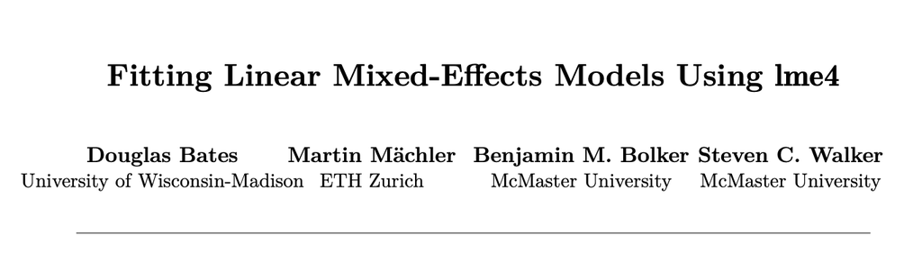

The notation is given in Table 2 of the paper:

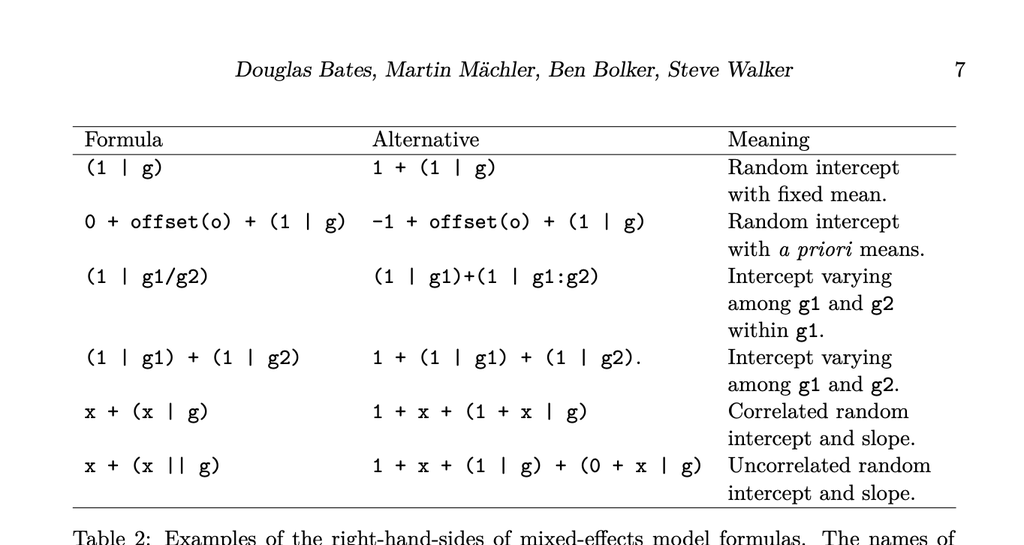

Looks like we want

```
(1 | paper/cohort)
```

## 3.2 Fit models

```r
tsh_glmer_M_paperRI  <- glmer(Sig ~ Thyroid_test + (1 | Paper),
                              data = TSH_long, family = binomial)
tsh_glmer_M_paper_cohort_RI  <- glmer(Sig ~ Thyroid_test + (1 | Paper / cohort),
                                      data = TSH_long, family = binomial)
tsh_glmer_M_no_test  <- glmer(Sig ~ 1 + (1 | Paper / cohort),
                              data = TSH_long, family = binomial)
```

## 3.3 Random terms

First test for whether need cohort RI:

```r
anova(tsh_glmer_M_paperRI, tsh_glmer_M_paper_cohort_RI)
```

```
## Data: TSH_long
## Models:
## tsh_glmer_M_paperRI: Sig ~ Thyroid_test + (1 | Paper)
## tsh_glmer_M_paper_cohort_RI: Sig ~ Thyroid_test + (1 | Paper/cohort)
##                             Df    AIC    BIC  logLik deviance  Chisq Chi Df
## tsh_glmer_M_paperRI          4 2050.6 2072.8 -1021.3   2042.6
## tsh_glmer_M_paper_cohort_RI  5 2013.3 2041.0 -1001.7   2003.3 39.291      1
##                             Pr(>Chisq)
## tsh_glmer_M_paperRI
## tsh_glmer_M_paper_cohort_RI  3.651e-10 ***
## ---
## Signif. codes:  0 '***' 0.001 '**' 0.01 '*' 0.05 '.' 0.1 ' ' 1
```

Small p-value so looks like we need cohort and paper RI.

## 3.4 Fixed effects

Now test for significant effect of test

```r
anova(tsh_glmer_M_paper_cohort_RI, tsh_glmer_M_no_test)
```

```
## Data: TSH_long
## Models:
## tsh_glmer_M_no_test: Sig ~ 1 + (1 | Paper/cohort)
## tsh_glmer_M_paper_cohort_RI: Sig ~ Thyroid_test + (1 | Paper/cohort)
##                             Df    AIC  BIC  logLik deviance  Chisq Chi Df
## tsh_glmer_M_no_test          3 2204.4 2221 -1099.2   2198.4
## tsh_glmer_M_paper_cohort_RI  5 2013.3 2041 -1001.7   2003.3 195.06      2
##                             Pr(>Chisq)
## tsh_glmer_M_no_test
## tsh_glmer_M_paper_cohort_RI  < 2.2e-16 ***
## ---
## Signif. codes:  0 '***' 0.001 '**' 0.01 '*' 0.05 '.' 0.1 ' ' 1
```

So still significant effect of type of test.

## 3.5 Final model

Look at effect of test.

```r
summary(tsh_glmer_M_paper_cohort_RI)
```

```
## Generalized linear mixed model fit by maximum likelihood (Laplace
##   Approximation) [glmerMod]
##  Family: binomial  ( logit )
## Formula: Sig ~ Thyroid_test + (1 | Paper/cohort)
##    Data: TSH_long
##
##      AIC      BIC   logLik deviance df.resid
##   2013.3   2041.0  -1001.7   2003.3     1875
##
## Scaled residuals:
##     Min      1Q  Median      3Q     Max
## -3.5618 -0.6225 -0.3021  0.6793  6.2259
##
## Random effects:
##  Groups       Name        Variance Std.Dev.
##  cohort:Paper (Intercept) 0.8083   0.8991
##  Paper        (Intercept) 1.0307   1.0152
## Number of obs: 1880, groups:  cohort:Paper, 142; Paper, 58
##
## Fixed effects:
##                 Estimate Std. Error z value Pr(>|z|)
## (Intercept)       0.3456     0.1892   1.826   0.0678 .
## Thyroid_testT3   -0.1404     0.1827  -0.768   0.4423
## Thyroid_testTSH  -1.6884     0.1332 -12.677   <2e-16 ***
## ---
## Signif. codes:  0 '***' 0.001 '**' 0.01 '*' 0.05 '.' 0.1 ' ' 1
##
## Correlation of Fixed Effects:
##             (Intr) Thy_T3
## Thyrd_tstT3 -0.196
## Thyrd_tsTSH -0.309  0.293
```

As before probability of significance is significantly lower than FT4 and T3.

## 3.6 Pairwise comparisons

```r
summary(glht(tsh_glmer_M_paper_cohort_RI, linfct = mcp(Thyroid_test = "Tukey")))
```

```
##
##   Simultaneous Tests for General Linear Hypotheses
##
## Multiple Comparisons of Means: Tukey Contrasts
##
##
## Fit: glmer(formula = Sig ~ Thyroid_test + (1 | Paper/cohort), data = TSH_long,
##     family = binomial)
##
## Linear Hypotheses:
##                Estimate Std. Error z value Pr(>|z|)
## T3 - FT4 == 0   -0.1404     0.1827  -0.768    0.719
## TSH - FT4 == 0  -1.6884     0.1332 -12.677   <1e-04 ***
## TSH - T3 == 0   -1.5480     0.1920  -8.063   <1e-04 ***
## ---
## Signif. codes:  0 '***' 0.001 '**' 0.01 '*' 0.05 '.' 0.1 ' ' 1
## (Adjusted p values reported -- single-step method)
```

## 3.7 Assumptions

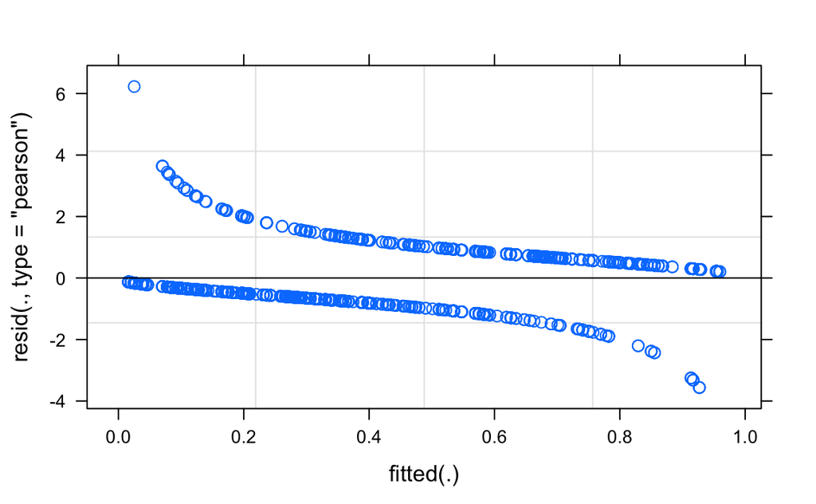

```r
plot(tsh_glmer_M_paper_cohort_RI)
```

# 4 Model to take into account style

Will be similar to above. First examine possible styles

```r
TSH_long %>%
  count(CvQ) %>%
  knitr::kable()
```

| CvQ | n |
| --- | --- |
| continuous | 1313 |
| dichotomous | 42 |
| performance | 48 |
| quartile | 228 |
| quintiles | 192 |
| tertiles | 57 |

Need to talk to NB about which to keep.

Decided that only keep those with number of obs greater than 10.

```r
TSH_long <-
  TSH_long %>%
  mutate(
    style = fct_lump_min(CvQ, min = 10)
  )
TSH_long %>%
  count(CvQ, style) %>%
  knitr::kable()
```

| CvQ | style | n |
| --- | --- | --- |
| continuous | continuous | 1313 |
| dichotomous | dichotomous | 42 |
| performance | performance | 48 |
| quartile | quartile | 228 |
| quintiles | quintiles | 192 |
| tertiles | tertiles | 57 |

## 4.1 Fit all models

```r
tsh_glmer_M_paperRI  <- glmer(Sig ~ Thyroid_test + (1 | Paper),
                              data = TSH_long, family = binomial)
tsh_glmer_M_paper_style_RI  <- glmer(Sig ~ Thyroid_test + (1 | Paper / style),
                                      data = TSH_long, family = binomial)
tsh_glmer_M_no_test  <- glmer(Sig ~ 1 + (1 | Paper / style),
                              data = TSH_long, family = binomial)
```

## 4.2 Random terms

```r
anova(tsh_glmer_M_paperRI, tsh_glmer_M_paper_style_RI)
```

```
## Data: TSH_long
## Models:
## tsh_glmer_M_paperRI: Sig ~ Thyroid_test + (1 | Paper)
## tsh_glmer_M_paper_style_RI: Sig ~ Thyroid_test + (1 | Paper/style)
##                            Df    AIC    BIC  logLik deviance  Chisq Chi Df
## tsh_glmer_M_paperRI         4 2050.6 2072.8 -1021.3   2042.6
## tsh_glmer_M_paper_style_RI  5 2049.2 2076.9 -1019.6   2039.2 3.3696      1
##                            Pr(>Chisq)
## tsh_glmer_M_paperRI
## tsh_glmer_M_paper_style_RI    0.06641 .
## ---
## Signif. codes:  0 '***' 0.001 '**' 0.01 '*' 0.05 '.' 0.1 ' ' 1
```

No significant effect of style.

# 5 Model to take into account sophistication

## 5.1 Check and clean

```r
TSH_long %>%
  count(Sophistication)
```

```
## # A tibble: 4 x 2
##   Sophistication     n
##   <chr>          <int>
## 1 Crude            515
## 2 High             301
## 3 Low              291
## 4 Medium           773
```

Need to remove NAs

```r
TSH_long_noNA  <-
  TSH_long %>%
  filter(!is.na(Sophistication))
```

Fit all models

```r
tsh_glmer_M_paperRI  <- glmer(Sig ~ Thyroid_test + (1 | Paper),
                              data = TSH_long_noNA, family = binomial)
tsh_glmer_M_paper_soph_RI  <- glmer(Sig ~ Thyroid_test + (1 | Paper / Sophistication),
                                      data = TSH_long_noNA, family = binomial)
tsh_glmer_M_no_test  <- glmer(Sig ~ 1 + (1 | Paper / cohort),
                              data = TSH_long_noNA, family = binomial)
```

## 5.2 Random effects

First test for whether need sophistication RI:

```r
anova(tsh_glmer_M_paperRI, tsh_glmer_M_paper_soph_RI)
```

```
## Data: TSH_long_noNA
## Models:
## tsh_glmer_M_paperRI: Sig ~ Thyroid_test + (1 | Paper)
## tsh_glmer_M_paper_soph_RI: Sig ~ Thyroid_test + (1 | Paper/Sophistication)
##                           Df    AIC    BIC  logLik deviance  Chisq Chi Df
## tsh_glmer_M_paperRI        4 2050.6 2072.8 -1021.3   2042.6
## tsh_glmer_M_paper_soph_RI  5 2051.8 2079.5 -1020.9   2041.8 0.7982      1
##                           Pr(>Chisq)
## tsh_glmer_M_paperRI
## tsh_glmer_M_paper_soph_RI     0.3716
```

## 5.3 Fixed effect

```r
anova(tsh_glmer_M_paper_soph_RI, tsh_glmer_M_no_test)
```

```
## Data: TSH_long_noNA
## Models:
## tsh_glmer_M_no_test: Sig ~ 1 + (1 | Paper/cohort)
## tsh_glmer_M_paper_soph_RI: Sig ~ Thyroid_test + (1 | Paper/Sophistication)
##                           Df    AIC    BIC  logLik deviance  Chisq Chi Df
## tsh_glmer_M_no_test        3 2204.4 2221.0 -1099.2   2198.4
## tsh_glmer_M_paper_soph_RI  5 2051.8 2079.5 -1020.9   2041.8 156.57      2
##                           Pr(>Chisq)
## tsh_glmer_M_no_test
## tsh_glmer_M_paper_soph_RI  < 2.2e-16 ***
## ---
## Signif. codes:  0 '***' 0.001 '**' 0.01 '*' 0.05 '.' 0.1 ' ' 1
```

So still significant effect of type of test.

## 5.4 Final model

```r
summary(tsh_glmer_M_paper_soph_RI)
```

```
## Generalized linear mixed model fit by maximum likelihood (Laplace
##   Approximation) [glmerMod]
##  Family: binomial  ( logit )
## Formula: Sig ~ Thyroid_test + (1 | Paper/Sophistication)
##    Data: TSH_long_noNA
##
##      AIC      BIC   logLik deviance df.resid
##   2051.8   2079.5  -1020.9   2041.8     1875
##
## Scaled residuals:
##     Min      1Q  Median      3Q     Max
## -3.3507 -0.6339 -0.3166  0.7111  3.9872
##
## Random effects:
##  Groups               Name        Variance Std.Dev.
##  Sophistication:Paper (Intercept) 0.05217  0.2284
##  Paper                (Intercept) 1.32552  1.1513
## Number of obs: 1880, groups:  Sophistication:Paper, 110; Paper, 58
##
## Fixed effects:
##                 Estimate Std. Error z value Pr(>|z|)
## (Intercept)       0.2902     0.1813   1.600    0.110
## Thyroid_testT3   -0.0933     0.1809  -0.516    0.606
## Thyroid_testTSH  -1.5893     0.1278 -12.434   <2e-16 ***
## ---
## Signif. codes:  0 '***' 0.001 '**' 0.01 '*' 0.05 '.' 0.1 ' ' 1
##
## Correlation of Fixed Effects:
##             (Intr) Thy_T3
## Thyrd_tstT3 -0.198
## Thyrd_tsTSH -0.309  0.283
```

## 5.5 Pairwise comparison

```r
summary(glht(tsh_glmer_M_paper_soph_RI, linfct = mcp(Thyroid_test = "Tukey")))
```

```
##
##   Simultaneous Tests for General Linear Hypotheses
##
## Multiple Comparisons of Means: Tukey Contrasts
##
##
## Fit: glmer(formula = Sig ~ Thyroid_test + (1 | Paper/Sophistication),
##     data = TSH_long_noNA, family = binomial)
##
## Linear Hypotheses:
##                Estimate Std. Error z value Pr(>|z|)
## T3 - FT4 == 0   -0.0933     0.1809  -0.516    0.861
## TSH - FT4 == 0  -1.5893     0.1278 -12.434   <1e-05 ***
## TSH - T3 == 0   -1.4960     0.1896  -7.889   <1e-05 ***
## ---
## Signif. codes:  0 '***' 0.001 '**' 0.01 '*' 0.05 '.' 0.1 ' ' 1
## (Adjusted p values reported -- single-step method)
```

# 6 Look at selected systems

```r
high_low_models  <- get_cov("high_low")
high_low_models %>% arrange(BIC) %>% knitr::kable()
```

| sigma | logLik | AIC | BIC | deviance | df.residual | null.deviance | df.null | converge | models |
| --- | --- | --- | --- | --- | --- | --- | --- | --- | --- |
| 1 | -1021.307 | 2050.615 | 2072.771 | 1889.363 | 1876 | NA | NA | TRUE | test + RI |
| 1 | -1021.131 | 2054.262 | 2087.497 | 1889.033 | 1874 | NA | NA | TRUE | test + main + RI |
| 1 | -1007.575 | 2035.149 | 2090.539 | 1861.236 | 1870 | NA | NA | TRUE | interaction + RI |
| NA | -1141.197 | 2300.394 | 2350.245 | 2282.394 | 1871 | 2503.245 | 1879 | TRUE | interaction |
| NA | -1156.571 | 2323.142 | 2350.837 | 2313.142 | 1875 | 2503.245 | 1879 | TRUE | test + main |
| NA | -1170.270 | 2346.539 | 2363.157 | 2340.539 | 1877 | 2503.245 | 1879 | TRUE | test |

# 7 Apply Devil’s Advocate

## 7.1 Small size, small model

```r
TSH_DA  <- TSH_long %>% filter(min_size_min_method)
TSH_DA
```

```
## # A tibble: 133 x 34
##    `hyper/hypo` Paper CvQ   Condition `NOS score` `TSH incong` `cross-section`
##    <chr>        <chr> <chr> <chr>           <dbl> <chr>        <chr>
##  1 Hyper        Capp… quar… Dementia           NA <NA>         <NA>
##  2 Hyper        Capp… quar… Dementia           NA <NA>         <NA>
##  3 Hyper        Chak… cont… AF preva…          NA <NA>         <NA>
##  4 Hyper        Chak… cont… AF preva…          NA <NA>         <NA>
##  5 Hyper        Chak… cont… AF incid…          NA <NA>         <NA>
##  6 Hyper        Chak… cont… AF incid…          NA <NA>         <NA>
##  7 Hyper        Gamm… cont… prevalen…          NA <NA>         <NA>
##  8 Hyper        Gamm… cont… prevalen…          NA <NA>         <NA>
##  9 Hyper        Heer… cont… AF incid…           8 0            N
## 10 Hyper        Heer… cont… AF incid…           8 0            N
## # … with 123 more rows, and 27 more variables: `abstract score` <chr>,
## #   ID <int>, system <chr>, cohort <chr>, min_size_min_method <lgl>,
## #   min_size_max_method <lgl>, max_size_min_method <lgl>,
## #   max_size_max_method <lgl>, Thyroid_test <fct>, N <dbl>, method <chr>,
## #   Sig <fct>, Sophistication <chr>, cov <chr>, total <chr>, inferred <lgl>,
## #   pv <dbl>, bounded <lgl>, OR <dbl>, ORCI <chr>, count <chr>, countCI <chr>,
## #   Thyroid_test_4 <chr>, high_low <chr>, n_cov <chr>, N_bin <fct>, style <fct>
```

```r
thyroid_model  <- glm(Sig ~ Thyroid_test,
             data = TSH_DA, family = binomial)
null_model  <- glm(Sig ~ 1,
             data = TSH_DA, family = binomial)
anova(null_model, thyroid_model, test = "LRT")
```

```
## Analysis of Deviance Table
##
## Model 1: Sig ~ 1
## Model 2: Sig ~ Thyroid_test
##   Resid. Df Resid. Dev Df Deviance  Pr(>Chi)
## 1       132     184.19
## 2       130     167.04  2   17.147 0.0001891 ***
## ---
## Signif. codes:  0 '***' 0.001 '**' 0.01 '*' 0.05 '.' 0.1 ' ' 1
```

```r
summary(glht(thyroid_model,
             linfct = mcp(Thyroid_test = "Tukey")))
```

```
##
##   Simultaneous Tests for General Linear Hypotheses
##
## Multiple Comparisons of Means: Tukey Contrasts
##
##
## Fit: glm(formula = Sig ~ Thyroid_test, family = binomial, data = TSH_DA)
##
## Linear Hypotheses:
##                Estimate Std. Error z value Pr(>|z|)
## T3 - FT4 == 0   -0.8369     0.5607  -1.493 0.290008
## TSH - FT4 == 0  -1.5995     0.4019  -3.980 0.000204 ***
## TSH - T3 == 0   -0.7626     0.5651  -1.349 0.363077
## ---
## Signif. codes:  0 '***' 0.001 '**' 0.01 '*' 0.05 '.' 0.1 ' ' 1
## (Adjusted p values reported -- single-step method)
```

## 7.2 Small size, large model

```r
TSH_DA  <- TSH_long %>% filter(min_size_max_method)
TSH_DA
```

```
## # A tibble: 133 x 34
##    `hyper/hypo` Paper CvQ   Condition `NOS score` `TSH incong` `cross-section`
##    <chr>        <chr> <chr> <chr>           <dbl> <chr>        <chr>
##  1 Hyper        Capp… cont… Dementia           NA <NA>         <NA>
##  2 Hyper        Capp… cont… Dementia           NA <NA>         <NA>
##  3 Hyper        Capp… cont… Dementia           NA <NA>         <NA>
##  4 Hyper        Chak… cont… AF preva…          NA <NA>         <NA>
##  5 Hyper        Chak… cont… AF preva…          NA <NA>         <NA>
##  6 Hyper        Chak… quar… AF incid…          NA <NA>         <NA>
##  7 Hyper        Chak… quar… AF incid…          NA <NA>         <NA>
##  8 Hyper        Gamm… cont… prevalen…          NA <NA>         <NA>
##  9 Hyper        Gamm… cont… prevalen…          NA <NA>         <NA>
## 10 Hyper        Heer… cont… AF incid…          NA <NA>         <NA>
## # … with 123 more rows, and 27 more variables: `abstract score` <chr>,
## #   ID <int>, system <chr>, cohort <chr>, min_size_min_method <lgl>,
## #   min_size_max_method <lgl>, max_size_min_method <lgl>,
## #   max_size_max_method <lgl>, Thyroid_test <fct>, N <dbl>, method <chr>,
## #   Sig <fct>, Sophistication <chr>, cov <chr>, total <chr>, inferred <lgl>,
## #   pv <dbl>, bounded <lgl>, OR <dbl>, ORCI <chr>, count <chr>, countCI <chr>,
## #   Thyroid_test_4 <chr>, high_low <chr>, n_cov <chr>, N_bin <fct>, style <fct>
```

```r
thyroid_model  <- glm(Sig ~ Thyroid_test,
             data = TSH_DA, family = binomial)
null_model  <- glm(Sig ~ 1,
             data = TSH_DA, family = binomial)
anova(null_model, thyroid_model, test = "LRT")
```

```
## Analysis of Deviance Table
##
## Model 1: Sig ~ 1
## Model 2: Sig ~ Thyroid_test
##   Resid. Df Resid. Dev Df Deviance Pr(>Chi)
## 1       132     182.68
## 2       130     168.35  2   14.331 0.000773 ***
## ---
## Signif. codes:  0 '***' 0.001 '**' 0.01 '*' 0.05 '.' 0.1 ' ' 1
```

```r
summary(glht(thyroid_model,
             linfct = mcp(Thyroid_test = "Tukey")))
```

```
##
##   Simultaneous Tests for General Linear Hypotheses
##
## Multiple Comparisons of Means: Tukey Contrasts
##
##
## Fit: glm(formula = Sig ~ Thyroid_test, family = binomial, data = TSH_DA)
##
## Linear Hypotheses:
##                Estimate Std. Error z value Pr(>|z|)
## T3 - FT4 == 0   -0.8492     0.5622  -1.510 0.281260
## TSH - FT4 == 0  -1.4576     0.3994  -3.649 0.000709 ***
## TSH - T3 == 0   -0.6084     0.5737  -1.060 0.533718
## ---
## Signif. codes:  0 '***' 0.001 '**' 0.01 '*' 0.05 '.' 0.1 ' ' 1
## (Adjusted p values reported -- single-step method)
```

## 7.3 Large size, small model

```r
TSH_DA  <- TSH_long %>% filter(max_size_min_method)
TSH_DA
```

```
## # A tibble: 134 x 34
##    `hyper/hypo` Paper CvQ   Condition `NOS score` `TSH incong` `cross-section`
##    <chr>        <chr> <chr> <chr>           <dbl> <chr>        <chr>
##  1 Hyper        Capp… quar… mortality          NA <NA>         <NA>
##  2 Hyper        Capp… quar… mortality          NA <NA>         <NA>
##  3 Hyper        Chak… cont… AF preva…           9 0            Y
##  4 Hyper        Chak… cont… AF preva…           9 0            Y
##  5 Hyper        Chak… cont… AF incid…          NA <NA>         N
##  6 Hyper        Chak… cont… AF incid…          NA <NA>         N
##  7 Hyper        Gamm… cont… AF preva…           9 0            Y
##  8 Hyper        Gamm… cont… AF preva…           9 0            Y
##  9 Hyper        Heer… cont… AF incid…           8 0            N
## 10 Hyper        Heer… cont… AF incid…           8 0            N
## # … with 124 more rows, and 27 more variables: `abstract score` <chr>,
## #   ID <int>, system <chr>, cohort <chr>, min_size_min_method <lgl>,
## #   min_size_max_method <lgl>, max_size_min_method <lgl>,
## #   max_size_max_method <lgl>, Thyroid_test <fct>, N <dbl>, method <chr>,
## #   Sig <fct>, Sophistication <chr>, cov <chr>, total <chr>, inferred <lgl>,
## #   pv <dbl>, bounded <lgl>, OR <dbl>, ORCI <chr>, count <chr>, countCI <chr>,
## #   Thyroid_test_4 <chr>, high_low <chr>, n_cov <chr>, N_bin <fct>, style <fct>
```

```r
thyroid_model  <- glm(Sig ~ Thyroid_test,
             data = TSH_DA, family = binomial)
null_model  <- glm(Sig ~ 1,
             data = TSH_DA, family = binomial)
anova(null_model, thyroid_model, test = "LRT")
```

```
## Analysis of Deviance Table
##
## Model 1: Sig ~ 1
## Model 2: Sig ~ Thyroid_test
##   Resid. Df Resid. Dev Df Deviance Pr(>Chi)
## 1       133     185.64
## 2       131     176.67  2    8.973  0.01126 *
## ---
## Signif. codes:  0 '***' 0.001 '**' 0.01 '*' 0.05 '.' 0.1 ' ' 1
```

```r
summary(glht(thyroid_model,
             linfct = mcp(Thyroid_test = "Tukey")))
```

```
##
##   Simultaneous Tests for General Linear Hypotheses
##
## Multiple Comparisons of Means: Tukey Contrasts
##
##
## Fit: glm(formula = Sig ~ Thyroid_test, family = binomial, data = TSH_DA)
##
## Linear Hypotheses:
##                Estimate Std. Error z value Pr(>|z|)
## T3 - FT4 == 0   -0.4925     0.5436  -0.906  0.63226
## TSH - FT4 == 0  -1.1343     0.3867  -2.933  0.00874 **
## TSH - T3 == 0   -0.6419     0.5464  -1.175  0.46337
## ---
## Signif. codes:  0 '***' 0.001 '**' 0.01 '*' 0.05 '.' 0.1 ' ' 1
## (Adjusted p values reported -- single-step method)
```

## 7.4 Large size, large model

```r
TSH_DA  <- TSH_long %>% filter(max_size_max_method)
TSH_DA
```

```
## # A tibble: 135 x 34
##    `hyper/hypo` Paper CvQ   Condition `NOS score` `TSH incong` `cross-section`
##    <chr>        <chr> <chr> <chr>           <dbl> <chr>        <chr>
##  1 Hyper        Capp… cont… Total Mo…          NA <NA>         <NA>
##  2 Hyper        Capp… cont… Total Mo…          NA <NA>         <NA>
##  3 Hyper        Capp… cont… Total Mo…          NA <NA>         <NA>
##  4 Hyper        Chak… cont… AF preva…          NA <NA>         <NA>
##  5 Hyper        Chak… cont… AF preva…          NA <NA>         <NA>
##  6 Hyper        Chak… cont… AF incid…          NA <NA>         <NA>
##  7 Hyper        Chak… cont… AF incid…          NA <NA>         <NA>
##  8 Hyper        Gamm… cont… AF preva…          NA <NA>         <NA>
##  9 Hyper        Gamm… cont… AF preva…          NA <NA>         <NA>
## 10 Hyper        Heer… cont… AF incid…          NA <NA>         <NA>
## # … with 125 more rows, and 27 more variables: `abstract score` <chr>,
## #   ID <int>, system <chr>, cohort <chr>, min_size_min_method <lgl>,
## #   min_size_max_method <lgl>, max_size_min_method <lgl>,
## #   max_size_max_method <lgl>, Thyroid_test <fct>, N <dbl>, method <chr>,
## #   Sig <fct>, Sophistication <chr>, cov <chr>, total <chr>, inferred <lgl>,
## #   pv <dbl>, bounded <lgl>, OR <dbl>, ORCI <chr>, count <chr>, countCI <chr>,
## #   Thyroid_test_4 <chr>, high_low <chr>, n_cov <chr>, N_bin <fct>, style <fct>
```

```r
thyroid_model  <- glm(Sig ~ Thyroid_test,
             data = TSH_DA, family = binomial)
null_model  <- glm(Sig ~ 1,
             data = TSH_DA, family = binomial)
anova(null_model, thyroid_model, test = "LRT")
```

```
## Analysis of Deviance Table
##
## Model 1: Sig ~ 1
## Model 2: Sig ~ Thyroid_test
##   Resid. Df Resid. Dev Df Deviance  Pr(>Chi)
## 1       134     183.87
## 2       132     169.22  2   14.651 0.0006587 ***
## ---
## Signif. codes:  0 '***' 0.001 '**' 0.01 '*' 0.05 '.' 0.1 ' ' 1
```

```r
summary(glht(thyroid_model,
             linfct = mcp(Thyroid_test = "Tukey")))
```

```
##
##   Simultaneous Tests for General Linear Hypotheses
##
## Multiple Comparisons of Means: Tukey Contrasts
##
##
## Fit: glm(formula = Sig ~ Thyroid_test, family = binomial, data = TSH_DA)
##
## Linear Hypotheses:
##                Estimate Std. Error z value Pr(>|z|)
## T3 - FT4 == 0   -0.9589     0.5461  -1.756    0.181
## TSH - FT4 == 0  -1.4730     0.4025  -3.660   <0.001 ***
## TSH - T3 == 0   -0.5142     0.5622  -0.914    0.627
## ---
## Signif. codes:  0 '***' 0.001 '**' 0.01 '*' 0.05 '.' 0.1 ' ' 1
## (Adjusted p values reported -- single-step method)
```